# Replicating the "Levelling up the United Kingdom" Deprivation Concentration plot

*Levi John Wolf*, University of Bristol

Like many people, I have been working through the UK Government's new [*Levelling Up the United Kingdom* report](https://www.gov.uk/government/publications/levelling-up-the-united-kingdom) and was struck by this very interesting figure they present in order to explain the distribution of income deprivation in the UK:

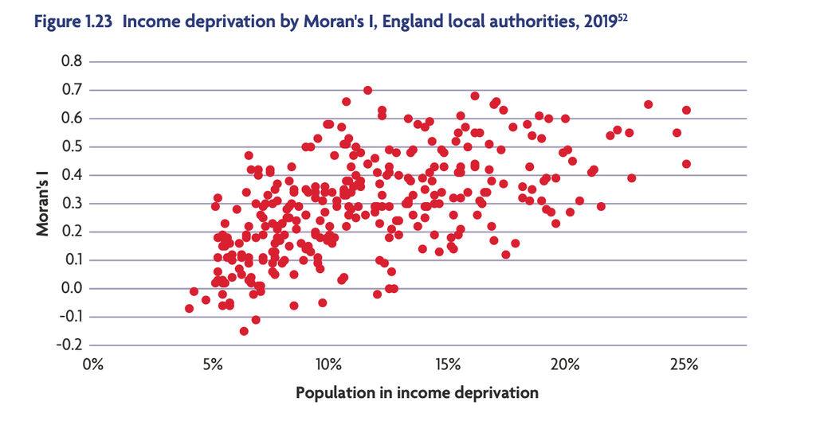

The plot shows the population percentage that is considered "Income deprived", relative to how clustered this income deprivation is. The plot suggests that the more income-deprived a local authority is, the more concentrated this income deprivation becomes within that local authority.

Since they provide us with [information on the data source](https://www.ons.gov.uk/peoplepopulationandcommunity/personalandhouseholdfinances/incomeandwealth/datasets/mappingincomedeprivationatalocalauthoritylevel), we can replicate this ourselves!

## Starting with a few libraries

```python
import pandas # for reading data
import geopandas # for reading spatial data

import matplotlib.pyplot as plt # baseline visualization package
import seaborn # a few more statistical tools for plotting
plt.style.use("seaborn-whitegrid") # picking a style for the plot
seaborn.set_context("poster")
```

Now, as [@darribas](https://twitter.com/darribas/status/1489162746046394369) notes, the "Moran's I" measure used in the report is a measure of *spatial autocorrelation*, which describes the relationship between near things. Here, we're using it as an indicator of *concentration*, suggesting that values close to 1 mean that income-deprived people live near income-deprived people.

To measure this, we need to load some spatial analytical libraries. I'm a lead author & maintainer of [PySAL](https://pysal.org), so I'll use two of its constituent libraries here

```python
from libpysal.weights import Queen # to describe which lsoas are "near" one another
from esda import Moran # to compute the Moran statistic
```

Then, we can read in the data from the ONS:

```python
detailed_deprivation = pandas.read_csv("https://assets.publishing.service.gov.uk/government/"
                                       "uploads/system/uploads/attachment_data/file/845345/"
                                       "File_7_-_All_IoD2019_Scores__Ranks__Deciles_and_Population_Denominators_3.csv")
```

And match it up to geographic boundary information (also from the [ONS](https://geoportal.statistics.gov.uk/datasets/lower-layer-super-output-areas-december-2011-boundaries-generalised-clipped-bgc-ew-v3/explore?location=52.559939%2C-2.489527%2C7.57), but stored on my website for ease of access...):

```python
lsoa_geojson = geopandas.read_file("https://raw.githubusercontent.com/ljwolf/ljwolf.github.io/master/notebooks/lsoa_geometries.geojson")
```

```python
lsoas = lsoa_geojson.merge(detailed_deprivation, left_on='LSOA11CD', right_on='LSOA code (2011)')
```

And, let's make a simple map of the data we're about to characterize:

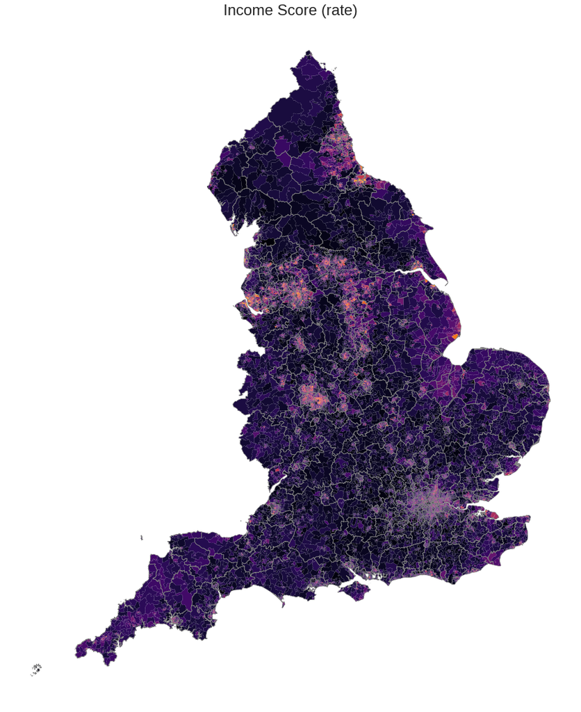

```python
f,ax = plt.subplots(1,1,figsize=(20,20))
lsoas.plot('Income Score (rate)', ax=ax, cmap='inferno')
las = lsoas.dissolve(by='Local Authority District name (2019)')
las.plot(ax=ax, facecolor='none', edgecolor='grey', linewidth=.7)
ax.set_axis_off()
ax.set_title("Income Score (rate)")
plt.show()
```

Now, to compute the graph's statistics, we need:

1. The Moran's I of population in Income Deprivation within each local authority
2. The total population in Income deprivation within each local authority.

Note that each of these just requires information about *each local authority*. So, we'll need to "split" our LSOAs by their local authorities, considering each one separately. So, I'll use a pandas `groupby` to split the data:

```python
grouper = lsoas.groupby("Local Authority District name (2019)")
```

Now, our first statistic can be computed directly from the `Income Score (rate)` variable provided by the ONS. Our second statistic (fraction of income-deprived population) will take a few steps. First, we'll need to compute the total population of each LSOA *times* its `Income Score (rate)` to get the total population in income deprivation in each LSOA. Then, we need to add this total income-deprived population together for each LSOA in a local authority to get the total percent of the local authority population in income deprivation.

Since we've already split our dataframe up by local authorities, we can write a function that *just* computes the statistic for one local authority. We do that below:

```python
def moran_chunk(chunk):
    """Compute Moran's I for a specific local authority "chunk" of our lsoa dataframe"""
    # Find out which LSOAs are next to one another
    w = Queen.from_dataframe(chunk)
    # If a local authority has more than one LSOA:
    if w.n > 1:
        # Compute the Moran's I among its LSOAs
        mo = Moran(chunk['Income Score (rate)'].values, w=w)
        I,p = mo.I, mo.p_sim
    else:
        # If not, just return it as missing
        I,p = None,None
    return (I,p)

def deprived_pop_frac(chunk):
    """Compute the fraction of population that is income-deprived within a local authority"""
    # The total population of the local authority
    total_pop = chunk['Total population: mid 2015 (excluding prisoners)'].sum()
    # The total income-deprived population of the local authority
    deprived_pop = (chunk['Total population: mid 2015 (excluding prisoners)']*chunk['Income Score (rate)']).sum()
    return deprived_pop/total_pop
```

Now, we can "apply" this function (yes, this is a [split-apply-combine pattern](https://pandas.pydata.org/pandas-docs/stable/user_guide/groupby.html) that we see often in data science) in order to get the Moran's I for each local authority:

```python
moran_stats = grouper.apply(moran_chunk)
```

From here, I'd like to clean this up a little bit, turning the single column of ($I$, $p$) pairs into a dataframe with two columns:

```python
moran_stats = moran_stats.apply(pandas.Series)
moran_stats.columns = ["Moran's I", 'p_value']
```

And, I'd like to make a new variable that records whether the Moran's I is "statistically significant" or not. Basically, if the Moran's $I$ is significanta, it means that the income-deprived population clusters more strongly than we'd expect to see just by randomly scattering people around the local authority.

```python
moran_stats['Significant'] = moran_stats.p_value < .01
```

```python
moran_stats.head()
```

| Local Authority District name (2019) | Moran's I | p_value | Significant |
| --- | --- | --- | --- |
| Adur | 0.158632 | 0.039 | False |
| Allerdale | 0.291921 | 0.001 | True |
| Amber Valley | 0.293332 | 0.001 | True |
| Arun | 0.310869 | 0.001 | True |
| Ashfield | 0.153217 | 0.013 | False |

Second, we can now compute the rates for the deprived population, and place that into a dataframe, too:

```python
rates = grouper.apply(deprived_pop_frac)
rates = rates.to_frame("Population in income deprivation")
```

```python
rates.head()
```

| Local Authority District name (2019) | Population in income deprivation |
| --- | --- |
| Adur | 0.107733 |
| Allerdale | 0.121175 |
| Amber Valley | 0.108693 |
| Arun | 0.103592 |
| Ashfield | 0.151681 |

Joining the two dataframes together gives us the data we need to make the plot:

```python
plot_data = moran_stats.join(rates).dropna()
plot_data.head()
```

| Local Authority District name (2019) | Moran's I | p_value | Significant | Population in income deprivation |
| --- | --- | --- | --- | --- |
| Adur | 0.158632 | 0.039 | False | 0.107733 |
| Allerdale | 0.291921 | 0.001 | True | 0.121175 |
| Amber Valley | 0.293332 | 0.001 | True | 0.108693 |
| Arun | 0.310869 | 0.001 | True | 0.103592 |
| Ashfield | 0.153217 | 0.013 | False | 0.151681 |

And now, the plot from the report, with a few embellishments:

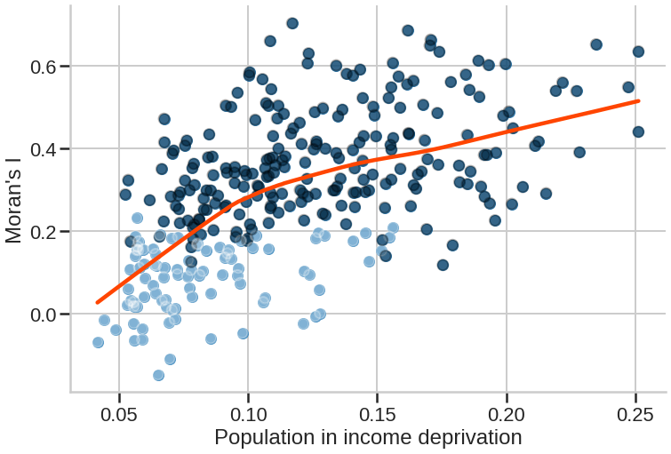

```python
f,ax = plt.subplots(1,1,figsize=(12,8))
ax = seaborn.regplot(data=plot_data,
                     x="Population in income deprivation",
                     y="Moran's I",
                     lowess=True,
                     line_kws=dict(color='orangered'),
                     ax=ax)
ax.scatter(plot_data['Population in income deprivation'],
           plot_data["Moran's I"],
           c=plot_data['Significant'],
           cmap='Greys',
           alpha=.3)
seaborn.despine(ax=ax)
plt.show()
```

Below, I'm adding a local kernel regression "trend line" to make the trend a bit more clear. Second, I'm also shading the points darker if they're "statistically signficiant", while making them lighter if they are not statistically signficiant.